# Data Cleaning Final Project

Author

Daniel Morehouse

This data set comes from my independent Marine Biology & Oceanography Research (MBOR) project that I conducted in Fall 2024 at the Bermuda Institute of Ocean Sciences. On 3 separate collection days, I incubated sponge fragments of 2 different species, one with an active chemical defense (T. ignis) and the other with no defense mechanism (D. etheria). Over the collection period, I wanted to determine if there was a change in thermal stress response between the 2 species. The data that will be used for this project comes from the first day of collection, 11/15/2024.

Through this data set, I wanted to answer 2 research questions:

- How does the surface area differ between the two experimental species?
- How does the respiration rate per hour differ between the ambient and heated treatments for each species?

In order to achieve these goals, I need to modify the data set to make it easier to work with. I’ll be cleaning this data set in 3 ways to answer my 2 research questions:

1. Renaming variables in order to manipulate them into code (including modifying variables with mutate)
2. Selecting only the variables needed for data visualizations
3. Reformatting correct oxygen hour & surface area as variable type doubles rather than character

Now that the data is thoroughly cleaned and read in, I can move forward and create the desired figures to hopefully answer my research questions.

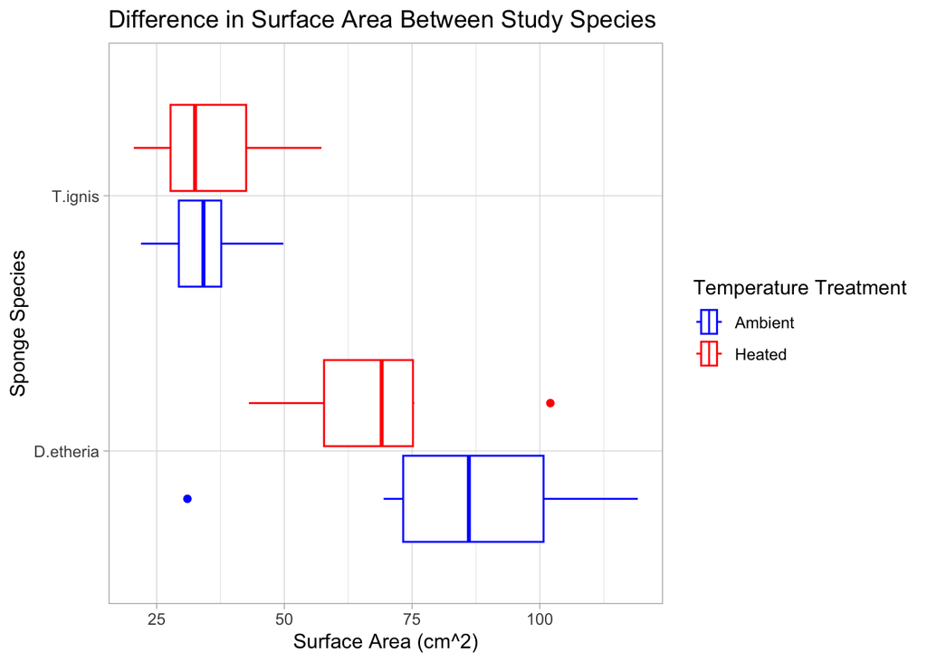

This figure shows that the fragments of D. etheria were greater in size than the fragments of T. ignis - which corresponds with my experience from sampling. This is an important variable to consider when evaluating respiration rate as a greater surface area could impact the amount of gas exchange occurring.

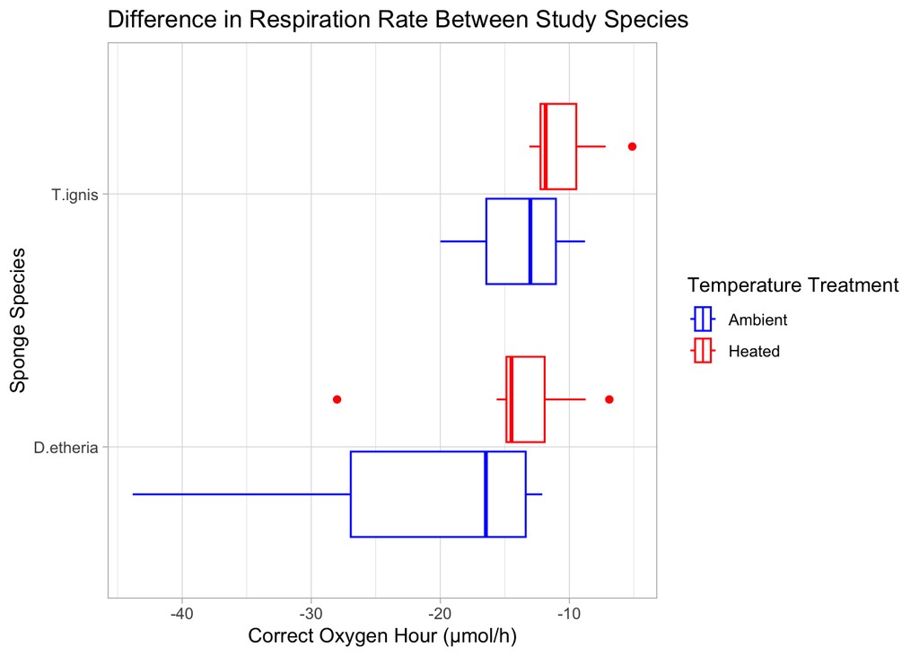